# Lab 1d

Operators

Statistical Programming with R

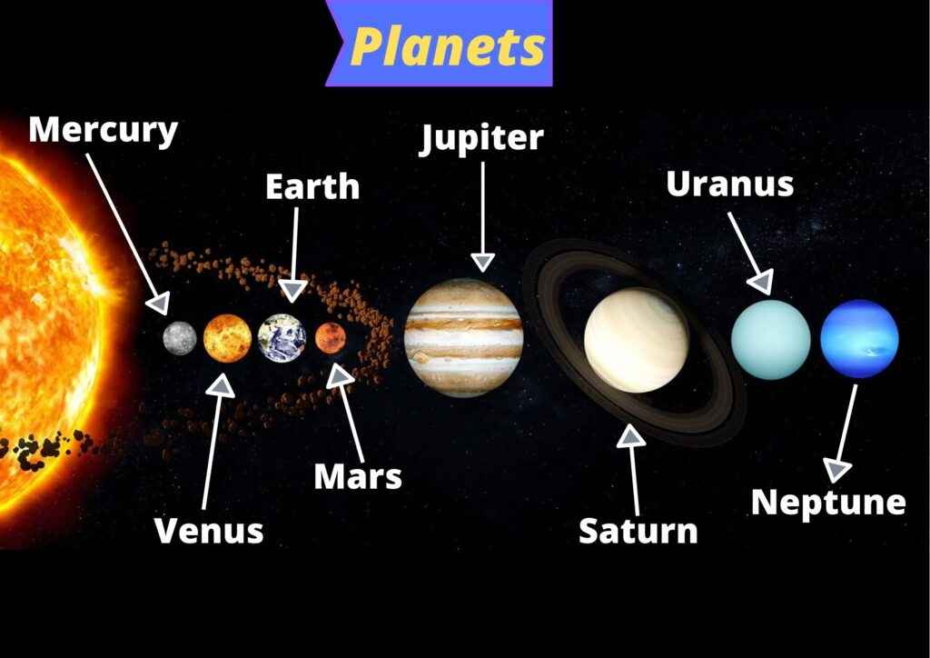

**Warning**: Before you can knit this file, download the image “planets.jpg” and place it in the same folder as your Rmd file.

Run the code below that makes 5 vectors containing information about planets.

```r
planet     <- c("Mercury", "Venus", "Earth", "Mars",
                "Jupiter", "Saturn", "Uranus", "Neptune")

type     <- c("Terrestrial planet", "Terrestrial planet",
              "Terrestrial planet", "Terrestrial planet", "Gas giant",
              "Gas giant", "Gas giant", "Gas giant")

diameter <- c(0.382, 0.949, 1, 0.532, 11.209, 9.449, 4.007, 3.883)

rotation <- c(58.64, -243.02, 1, 1.03, 0.41, 0.43, -0.72, 0.67)

rings    <- c(FALSE, FALSE, FALSE, FALSE, TRUE, TRUE, TRUE, TRUE)
```

# 1 Subsetting vectors

1. Display the 2nd element of `rotation`.

```r
rotation[2]
```

```
[1] -243.02
```

4. Display the 1st and 2nd element of `planet`.

```r
planet[1:2]
```

```
[1] "Mercury" "Venus"
```

4. Display a logical vector with `TRUE` when `diameter > 1` and `FALSE` otherwise.

```r
diameter > 1
```

```
[1] FALSE FALSE FALSE FALSE  TRUE  TRUE  TRUE  TRUE
```

6. Display the planets with a diameter greater than 1.

```r
planet[diameter > 1]
```

```
[1] "Jupiter" "Saturn"  "Uranus"  "Neptune"
```

# 2 Subsetting data frames

```r
planets <- data.frame(type = factor(type), diameter, rotation, rings, row.names = planet)
```

2. Remove the five vectors from workspace with the function `rm()`.

```r
rm(name, type, diameter, rotation, rings)
```

2. Display the classes of the variables in `planets` with the function `sapply()`.

```r
sapply(planets, class)
```

```
     type  diameter  rotation     rings
 "factor" "numeric" "numeric" "logical"
```

3. Display the summary of `planets`.

```r
summary(planets)
```

```
                 type      diameter          rotation           rings
 Gas giant         :4   Min.   : 0.3820   Min.   :-243.0200   Mode :logical
 Terrestrial planet:4   1st Qu.: 0.8448   1st Qu.:   0.1275   FALSE:4
                        Median : 2.4415   Median :   0.5500   TRUE :4
                        Mean   : 3.9264   Mean   : -22.6950
                        3rd Qu.: 5.3675   3rd Qu.:   1.0075
                        Max.   :11.2090   Max.   :  58.6400
```

```r
planets$type
```

```
[1] Terrestrial planet Terrestrial planet Terrestrial planet Terrestrial planet Gas giant          Gas giant          Gas giant          Gas giant
Levels: Gas giant Terrestrial planet
```

4. Display the variable `diameter` of `planets` using the dollar sign.

```r
planets$diameter
```

```
[1]  0.382  0.949  1.000  0.532 11.209  9.449  4.007  3.883
```

# 3 Lists

```r
planets_list <- list(planets       = planets,
                     type_levels   = levels(planets$type),
                     mean_rotation = mean(planets$rotation))
```

2. Display the third element of the list using double square brackets.

```r
planets_list[[3]]
```

```
[1] -22.695
```

3. Display the second element of the list using the dollar sign.

```r
planets_list$type_levels
```

```
[1] "Gas giant"          "Terrestrial planet"
```

# 4 Advanced

1. Display from the first list element (the data frame `planets`) the second and fourth element of the variable `rotation`.

```r
planets_list$planets$rotation[c(2, 4)]
```

```
[1] -243.02    1.03
```